# Chapter 3

### Lee Sang Yoon (2016270905)

# 3.6 Exercises

## 1. What will this conditional expression return?

```r
x <- c(1,2,-3,4)

if(all(x>0)){
  print("All Postives")
} else{
  print("Not all positives")
}
```

```
## [1] "Not all positives"
```

## 2. Which of the following expressions is always FALSE when at least one entry of a logical vector x is TRUE?

### d. all(!x)

```r
# 답: d
```

```r
library(dslabs)
a<-nchar(murders$state)
ifelse(a<8, murders$state, murders$abb)
```

```
##  [1] "Alabama" "Alaska"  "Arizona" "AR"      "CA"      "CO"      "CT"
##  [8] "DE"      "DC"      "Florida" "Georgia" "Hawaii"  "Idaho"   "IL"
## [15] "Indiana" "Iowa"    "Kansas"  "KY"      "LA"      "Maine"   "MD"
## [22] "MA"      "MI"      "MN"      "MS"      "MO"      "Montana" "NE"
## [29] "Nevada"  "NH"      "NJ"      "NM"      "NY"      "NC"      "ND"
## [36] "Ohio"    "OK"      "Oregon"  "PA"      "RI"      "SC"      "SD"
## [43] "TN"      "Texas"   "Utah"    "Vermont" "VA"      "WA"      "WV"
## [50] "WI"      "Wyoming"
```

## 4. Create a function sum_n that for any given value, say n, computes the sum of the integers from 1 to n (inclusive). Use the function to determine the sum of integers from 1 to 5,000.

```r
sum_n<- function(n){
  sum(1:n)
}
n<-5000
sum_n(5000)
```

```
## [1] 12502500
```

## 5. Create a function altman_plot that takes two arguments, x and y, and plots the difference against the sum.

```r
# plots the difference against the sum = sum을 x축, difference를 y축으로 하는 그래프

altman_plot<- function(x, y){
  plot(x+y, y-x)
}
# in general, y indicates outcome (ex.y=x) so it's y-x
altman_plot
```

```
## function(x, y){
##   plot(x+y, y-x)
## }
```

## 6. After running the code below, what is the value of x?

```r
x <- 3
my_func <- function(y){
  x <- 5
  y+5
}
x
```

```
## [1] 3
```

```r
# 이를 통해 function 내부에서 정의된 변수는 workspace에 저장되지 않음을 알 수 있었다.
```

## 7. Write a function compute_s_n that for any given n computes the sum Sn= 1^2 +2^2 +3^2 +… n^2. Report the value of the sum when n=10.

```r
compute_s_n<- function(n){
  x<-1:n
  sum(x^2)
}
n=10
compute_s_n(10)
```

```
## [1] 385
```

## 8. Define an empty numerical vector s_n of size 25 using s_n <- vector(“numeric”, 25) and store in the results of S1,S2,…S25 using a for-loop.

```r
s_n<- vector("numeric", 25)
m<- 25
for(n in 1:m){
  s_n[n]<- compute_s_n(n)
}
s_n[m]
```

```
## [1] 5525
```

## 9. Repeat exercise 8, but this time use sapply.

```r
n<-1:25
s_n<- sapply(n, compute_s_n)
s_n
```

```
##  [1]    1    5   14   30   55   91  140  204  285  385  506  650  819 1015 1240
## [16] 1496 1785 2109 2470 2870 3311 3795 4324 4900 5525
```

## 10. Repeat exercise 8, but this time use map_dbl.

```r
?map_dbl
```

```
## 다음과 같이  지정된 패키지들과 라이브러리들에서 'map_dbl'에 대한 문서를 찾을 수 없습니다:
## '??map_dbl'를 시도해보세요
```

```r
library("tidyverse")
```

```r
map_dbl(n, compute_s_n)
```

```
##  [1]    1    5   14   30   55   91  140  204  285  385  506  650  819 1015 1240
## [16] 1496 1785 2109 2470 2870 3311 3795 4324 4900 5525
```

## 11. Plot Sn versus n. Use points defined by n=1,…,25.

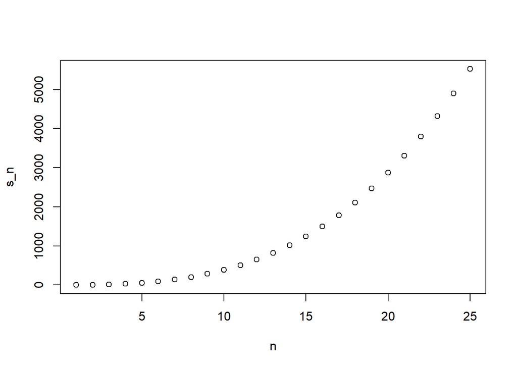

```r
plot(n, s_n)
```

## 12. Confirm that the formula for this sum is Sn=n(n+1)(2n+1)/6.

```r
compute_s_n<- function(n){
  x<-1:n
  sum(x^2)
}

Sn<- sapply(n, compute_s_n)

s_n_3<- function(n){
  x<- n*(n+1)*(2*n+1)/6
  x
  }


identical(s_n_3(n), Sn)
```

```
## [1] TRUE
```

```r
#???,,,,
```